# BME4550_Fall2018_Assignment4

Monika Grabowska

September 25, 2018

## Chapter 18 - no exercises

## 19.2.1 Practice

### 1. Why is `TRUE` not a parameter to `rescale01()`? What would happen if `x` contained a single missing value, and `na.rm` was `FALSE`?

`TRUE` is not a parameter to `rescale01()` because we don’t want it to be a parameter of a function that the user can change. If `x` contains a missing value and `na.rm` is `FALSE` then the output vector will have an NA value.

### 2. In the second variant of `rescale01()`, infinite values are left unchanged. Rewrite `rescale01()` so that -`Inf` is mapped to 0, and `Inf` is mapped to 1.

```r
rescale01 <- function(x) {
  rng <- range(x, na.rm = TRUE, finite = TRUE)
  (x - rng[1]) / (rng[2] - rng[1])
  x[x == -Inf] <- 0
  x[x == Inf] <- 1
  return(x)
}
rescale01(c(5,NA,-Inf,10,Inf))
```

```
## [1]  5 NA  0 10  1
```

### 3. Practice turning the following code snippets into functions. Think about what each function does. What would you call it? How many arguments does it need? Can you rewrite it to be more expressive or less duplicative?

```
mean(is.na(x))

x / sum(x, na.rm = TRUE)

sd(x, na.rm = TRUE) / mean(x, na.rm = TRUE)
```

```
prop_NA <- function(x) {
  return(mean(is.na(x)))
}

to_weights <- function(x) {
  x / sum(x, na.rm = TRUE)
}

coeff_var <- function(x) {
  return(sd(x, na.rm = TRUE) / mean(x, na.rm = TRUE))
}
```

### 4. Follow http://nicercode.github.io/intro/writing-functions.html to write your own functions to compute the variance and skew of a numeric vector.

```r
variance <- function(x) {
  diff_from_mean <- (x - mean(x, rm.na = TRUE))
  sum_of_squares <- sum(diff_from_mean^2, rm.na = TRUE)
  return(sum_of_squares/(sum(!is.na(x)) - 1))
}
variance(c(1,10,12,2))
```

```
## [1] 31.25
```

```r
skewness <- function(x) {
  diff_from_mean <- (x - mean(x, rm.na = TRUE))
  third_moment <- sum(diff_from_mean^3, na.rm = TRUE)
  std_cubed <- sum(diff_from_mean^2, na.rm = TRUE)^(3/2)/sqrt(sum(!is.na(x)))
  return(third_moment/std_cubed)
}
skewness(c(1,10,12,2))
```

```
## [1] 0.04785918
```

### 5. Write `both_na()`, a function that takes two vectors of the same length and returns the number of positions that have an `NA` in both vectors.

```r
both_na <- function(x, y){
  x <- is.na(x)
  y <- is.na(y)
  return(sum(x & y))
}
both_na(c(1,NA,NA,NA,5), c(1,NA,7,NA,NA))
```

```
## [1] 2
```

### 6. What do the following functions do? Why are they useful even though they are so short?

```r
is_directory <- function(x) file.info(x)$isdir
is_readable <- function(x) file.access(x, 4) == 0
```

`is_directory()` returns `TRUE` if `x` is a directory and `FALSE` otherwise. `is_readable()` returns `TRUE` if a file can be read. They are useful because their function names reveal more about their function than the actual code.

### 7. Read the complete lyrics to “Little Bunny Foo Foo”. There’s a lot of duplication in this song. Extend the initial piping example to recreate the complete song, and use functions to reduce the duplication.

```r
foofoo <- function() {
  first <- "Little bunny Foo Foo\nHopping through the forest\nScooping up the field mice\nAnd bopping them on the head"
  second <-"Down came the Good Fairy, and she said\n\"Little bunny Foo Foo\nI don't want to see you\nScooping up the field mice\nAnd bopping them on the head.\""
  cat(second)
  i <- 3
  while(i > 0){
    word <- switch(i,
                   'one',
                   'two',
                   'three'
                   )
    third <- paste0("I'll give you ", word, " chances,\nAnd if you don't behave, I will turn you into a goon!\"\nAnd the next day...")
    cat(first, second, third, sep = "\n\n")
    i <- i - 1
  }
  final <- "I gave you three chances and you didn't behave so....\nPOOF. She turned him into a Goon."
  cat(first, second, final, sep = "\n\n")

}
foofoo()
```

```
## Down came the Good Fairy, and she said
## "Little bunny Foo Foo
## I don't want to see you
## Scooping up the field mice
## And bopping them on the head."Little bunny Foo Foo
## Hopping through the forest
## Scooping up the field mice
## And bopping them on the head
##
## Down came the Good Fairy, and she said
## "Little bunny Foo Foo
## I don't want to see you
## Scooping up the field mice
## And bopping them on the head."
##
## I'll give you three chances,
## And if you don't behave, I will turn you into a goon!"
## And the next day...
## Little bunny Foo Foo
## Hopping through the forest
## Scooping up the field mice
## And bopping them on the head
##
## Down came the Good Fairy, and she said
## "Little bunny Foo Foo
## I don't want to see you
## Scooping up the field mice
## And bopping them on the head."
##
## I'll give you two chances,
## And if you don't behave, I will turn you into a goon!"
## And the next day...
## Little bunny Foo Foo
## Hopping through the forest
## Scooping up the field mice
## And bopping them on the head
##
## Down came the Good Fairy, and she said
## "Little bunny Foo Foo
## I don't want to see you
## Scooping up the field mice
## And bopping them on the head."
##
## I'll give you one chances,
## And if you don't behave, I will turn you into a goon!"
## And the next day...
## Little bunny Foo Foo
## Hopping through the forest
## Scooping up the field mice
## And bopping them on the head
##
## Down came the Good Fairy, and she said
## "Little bunny Foo Foo
## I don't want to see you
## Scooping up the field mice
## And bopping them on the head."
##
## I gave you three chances and you didn't behave so....
## POOF. She turned him into a Goon.
```

## 19.3.1 Exercises

### 1. Read the source code for each of the following three functions, puzzle out what they do, and then brainstorm better names.

```r
f1 <- function(string, prefix) {
  substr(string, 1, nchar(prefix)) == prefix
}
f2 <- function(x) {
  if (length(x) <= 1) return(NULL)
  x[-length(x)]
}
f3 <- function(x, y) {
  rep(y, length.out = length(x))
}
```

`f1` tests whether each element of the character vector nchar starts with the string prefix. A better name for `f1` would be `has_prefix()`.

`f2` drops the last element of the vector x, thus a better name for `f2` would be `drop_last()`.

`f3` repeats y once for each element of x. A better name for `f3` would be `repeat_y()`.

### 2. Take a function that you’ve written recently and spend 5 minutes brainstorming a better name for it and its arguments.

Function: analyze_f3, better name would be analyze_pop. Arguments: target population, could call this pop_target.

### 3. Compare and contrast `rnorm()` and `MASS::mvrnorm()`. How could you make them more consistent?

`rnorm()` samples from the univariate normal distribution, whereas `MASS::mvrnorm()` samples from the multivariate normal distribution. `rnorm()` takes the arguments n, mean, and sd, whereas `MASS::mvrnorm()` takes the arguments n, mu, and Sigma. To make them more consistent you could make them take arguments with the same names.

### 4. Make a case for why `norm_r()`, `norm_d()` etc would be better than `rnorm()`, `dnorm()`. Make a case for the opposite.

`norm_r()` and `norm_d()` would be better because then the naming convention would group functions by their distribution. However, with `rnorm()` and `dnorm()`, the naming convention would group functions by the action they perform, which is also advantageous.

## 19.4.4 Exercises

### 1. What’s the difference between `if` and `ifelse()`? Carefully read the help and construct three examples that illustrate the key differences.

`if` tests a single condition, whereas `ifelse()` tests each element.

```r
if (TRUE) {
  print("Yes")
} else {
  print("No")
}
```

```
## [1] "Yes"
```

```r
ifelse(c(TRUE, FALSE, FALSE, TRUE), "Yes", "No")
```

```
## [1] "Yes" "No"  "No"  "Yes"
```

### 2. Write a greeting function that says “good morning”, “good afternoon”, or “good evening”, depending on the time of day. (Hint: use a time argument that defaults to `lubridate::now()`. That will make it easier to test your function.)

```r
greet <- function(time = lubridate::now()) {
  hr <- lubridate::hour(time)
  if (hr < 12) {
    print("good morning")
  } else if (hr < 17) {
    print("good afternoon")
  } else {
    print("good evening")
  }
}
greet()
```

```
## [1] "good evening"
```

### 3. Implement a `fizzbuzz` function. It takes a single number as input. If the number is divisible by three, it returns “fizz”. If it’s divisible by five it returns “buzz”. If it’s divisible by three and five, it returns “fizzbuzz”. Otherwise, it returns the number. Make sure you first write working code before you create the function.

```r
fizzbuzz <- function(x) {
  stopifnot(length(x) == 1)
  stopifnot(is.numeric(x))
  if (!(x %% 3) && !(x %% 5)) {
    "fizzbuzz"
  } else if (!(x %% 3)) {
    "fizz"
  } else if (!(x %% 5)) {
    "buzz"
  } else {
    x
  }
}
fizzbuzz(9)
```

```
## [1] "fizz"
```

```r
fizzbuzz(15)
```

```
## [1] "fizzbuzz"
```

```r
fizzbuzz(2)
```

```
## [1] 2
```

```r
fizzbuzz(10)
```

```
## [1] "buzz"
```

### 4. How could you use `cut()` to simplify this set of nested if-else statements?

```
if (temp <= 0) {
  "freezing"
} else if (temp <= 10) {
  "cold"
} else if (temp <= 20) {
  "cool"
} else if (temp <= 30) {
  "warm"
} else {
  "hot"
}
```

Using `cut()`:

```
cut(temp, breaks = seq(-10, 40, 10),
    labels = c("freezing", "cold", "cool", "warm", "hot"))
```

### How would you change the call to `cut()` if I’d used `<` instead of `<=`? What is the other chief advantage of `cut()` for this problem? (Hint: what happens if you have many values in `temp`?)

Changed call to `cut()`:

```
cut(temp, breaks = seq(-10, 40, 10),
    right = FALSE,
    labels = c("freezing", "cold", "cool", "warm", "hot"))
```

The advantages of using `cut()` are that it works on vectors (whereas `if` only works on a single value) and that it is easier to change comparisons using `cut()` (would only need to change the argument to `right` compared to changing four operators if had used `if`).

### 5. What happens if you use `switch()` with numeric values?

```r
switch(1, "No", "Yes", "Maybe")
```

```
## [1] "No"
```

```r
switch(2, "No", "Yes", "Maybe")
```

```
## [1] "Yes"
```

If you use `switch()` with numeric values (as in `switch(n, ...)`), then it will return the nth argument in …, as shown above.

### 6. What does this `switch()` call do? What happens if x is “e”?

```r
x <- "b"
switch(x,
  a = ,
  b = "ab",
  c = ,
  d = "cd"
)
```

```
## [1] "ab"
```

```r
x <- "a"
switch(x,
  a = ,
  b = "ab",
  c = ,
  d = "cd"
)
```

```
## [1] "ab"
```

```r
x <- "e"
switch(x,
  a = ,
  b = "ab",
  c = ,
  d = "cd"
)
```

## 19.5.5 Exercises

### 1. What does `commas(letters, collapse = "-")` do? Why?

```r
commas <- function(...) {
  stringr::str_c(..., collapse = ", ")
}
commas(letters, collapse = "-")
```

```
## Error in stringr::str_c(..., collapse = ", "): formal argument "collapse" matched by multiple actual arguments
```

`commas(letters, collapse = "-")` throws an error because the `collapse` argument is passed to `str_c` in the `commas` function, which already has the argument `collapse = ", "`.

You could get letters separated by “-” if you did:

```r
commas <- function(..., collapse = ",") {
  str_c(..., collapse = collapse)
}
commas(letters, collapse = "-")
```

```
## [1] "a-b-c-d-e-f-g-h-i-j-k-l-m-n-o-p-q-r-s-t-u-v-w-x-y-z"
```

### 2. It’d be nice if you could supply multiple characters to the `pad` argument, e.g. `rule("Title", pad = "-+")`. Why doesn’t this currently work? How could you fix it?

This doesn’t currently work because the original `rule` function copies the `pad` argument a very specific number of times (equal to the desired width minus the length of the title and five extra characters) - if `pad` is 2 characters rather than 1 then the output is almost twice as long.

Original:

```r
rule <- function(..., pad = "-") {
  title <- paste0(...)
  width <- getOption("width") - nchar(title) - 5
  cat(title, " ", stringr::str_dup(pad, width), "\n", sep = "")
}
rule("Title", pad = "-+")
```

```
## Title -+-+-+-+-+-+-+-+-+-+-+-+-+-+-+-+-+-+-+-+-+-+-+-+-+-+-+-+-+-+-+-+-+-+-+-+-+-+-+-+-+-+-+-+-+-+-+-+-+-+-+-+-+-+-+-+-+-+-+-+-+-+-+-+-+
```

Fixed:

```r
rule <- function(..., pad = "-") {
  title <- paste0(...)
  width <- getOption("width") - nchar(title) - 5
  pad_char <- nchar(pad)
  cat(title, " ", stringr::str_dup(pad, width / pad_char), "\n", sep = "")
}
rule("Title", pad = "-+")
```

```
## Title -+-+-+-+-+-+-+-+-+-+-+-+-+-+-+-+-+-+-+-+-+-+-+-+-+-+-+-+-+-+-+-+
```

### 3. What does the trim argument to `mean()` do? When might you use it?

The trim argument to `mean()` trims a specified fraction of observations off each end of the vector before calculating the mean. This is useful for excluding outliers.

Example: Trimming 10 percent of observations off each end of the vector

```r
mean(c(99, 1:10))
```

```
## [1] 14
```

```r
mean(c(99, 1:10), trim = 0.1)
```

```
## [1] 6
```

### 4. The default value for the method argument to `cor()` is `c("pearson", "kendall", "spearman")`. What does that mean? What value is used by default?

That means the method argument can take any one of those 3 values. The default is the first value, i.e. “pearson”.

## 20.3.5 Exercises

### 1. Describe the difference between `is.finite(x)` and `!is.infinite(x)`.

```r
x <- c(0, NA, NaN, Inf, -Inf)
is.finite(x)
```

```
## [1]  TRUE FALSE FALSE FALSE FALSE
```

```r
!is.infinite(x)
```

```
## [1]  TRUE  TRUE  TRUE FALSE FALSE
```

`is.finite(x)` considers non-missing numeric values (ex. 0) to be finite, while values that are missing (NA), not a number (NaN), positive infinity (Inf), or negative infinity (-Inf) are not finite. `!is.finite(x)` considers non-missing numeric, NA, and NaN values to be finite, while Inf and -Inf are not finite.

### 2. Read the source code for `dplyr::near()` (Hint: to see the source code, drop the `()`). How does it work?

```r
dplyr::near
```

```
## function (x, y, tol = .Machine$double.eps^0.5)
## {
##     abs(x - y) < tol
## }
## <environment: namespace:dplyr>
```

`dplyr::near()` checks that two numbers are within a certain tolerance (tol). The default value of tol is the square root of .Machine$double.eps.

### 3. A logical vector can take 3 possible values. How many possible values can an integer vector take? How many possible values can a double take? Use google to do some research.

Integer vectors have 32-bit representation in R, thus an integer vector can take 2^32 possible values. Double vectors have 64-bit representation in R, thus a double vector can take 2^64 possible values.

### 4. Brainstorm at least four functions that allow you to convert a double to an integer. How do they differ? Be precise.

```r
x <- seq(-5, 5, by = 0.5)
as.integer(x) # coerces its argument to be an integer
```

```
##  [1] -5 -4 -4 -3 -3 -2 -2 -1 -1  0  0  0  1  1  2  2  3  3  4  4  5
```

```r
floor(x) # rounds down
```

```
##  [1] -5 -5 -4 -4 -3 -3 -2 -2 -1 -1  0  0  1  1  2  2  3  3  4  4  5
```

```r
ceiling(x) # rounds up
```

```
##  [1] -5 -4 -4 -3 -3 -2 -2 -1 -1  0  0  1  1  2  2  3  3  4  4  5  5
```

```r
`%/%`(x, 1) # extracts the integer part of x
```

```
##  [1] -5 -5 -4 -4 -3 -3 -2 -2 -1 -1  0  0  1  1  2  2  3  3  4  4  5
```

### 5. What functions from the readr package allow you to turn a string into logical, integer, and double vector?

`parse_logical()`, `parse_integer()`, and `parse_double()` allow you to turn a string into a logical, integer, and double vector (see example below).

```r
x <- c("TRUE", "FALSE")
parse_logical(x)
```

```
## [1]  TRUE FALSE
```

```r
x <- c("1", "2")
parse_integer(x)
```

```
## [1] 1 2
```

```r
x <- c("1.1", "1.2")
parse_double(x)
```

```
## [1] 1.1 1.2
```

## 20.4.6 Exercises

### 1. What does `mean(is.na(x))` tell you about a vector `x`? What about `sum(!is.finite(x))`?

`mean(is.na(x))` gives the proportion of missing values in the vector, while `sum(!is.finite(x))` gives the number of not finite values in the vector.

### 2. Carefully read the documentation of `is.vector()`. What does it actually test for? Why does `is.atomic()` not agree with the definition of atomic vectors above?

`is.vector()` only tests if x is a vector of the specified mode having no attributes other than names. `is.atomic()` tests for the atomic types (“logical”, “integer”, “numeric”, “complex”, “character” and “raw”) and NULL.

### 3. Compare and contrast `setNames()` with `purrr::set_names()`.

`purrr::set_names()`has more ways to set the names than `setNames()`. Also, with `purrr::set_names()`, you can use a function to transform the existing names.

```r
purrr::set_names(c(a = 1, b = 2, c = 3), toupper)
```

```
## A B C
## 1 2 3
```

### 4. Create functions that take a vector as input and returns: 1) The last value. Should you use `[` or `[[`? 2) The elements at even numbered positions. 3) Every element except the last value. 4) Only even numbers (and no missing values).

```r
x <- c(-3, -1, 0, 1, 5, 10, NA)
```

```r
last_value <- function(x) {
  x[[length(x)]]
}
last_value(x)
```

```
## [1] NA
```

```r
even_positions <- function(x) {
  x[seq(2, length(x), 2)]
}
even_positions(x)
```

```
## [1] -1  1 10
```

```r
except_last <- function(x) {
  x[1:(length(x)-1)]
}
except_last(x)
```

```
## [1] -3 -1  0  1  5 10
```

```r
even_numbers <- function(x) {
  x[x %% 2 == 0 & !is.na(x)]
}
even_numbers(x)
```

```
## [1]  0 10
```

### 5. Why is `x[-which(x > 0)]` not the same as `x[x <= 0]`?

`x[-which(x > 0)]` and `x[x <= 0]` handle missing values differently. This is because `which()` leaves NA and NaN values alone, while `<=` turns NaN values into NA values.

```r
x <- c(-5:5, Inf, -Inf, NaN, NA)
x[-which(x > 0)]
```

```
## [1]   -5   -4   -3   -2   -1    0 -Inf  NaN   NA
```

```r
x[x <= 0]
```

```
## [1]   -5   -4   -3   -2   -1    0 -Inf   NA   NA
```

### 6. What happens when you subset with a positive integer that’s bigger than the length of the vector? What happens when you subset with a name that doesn’t exist?

If you subset with a positive integer that’s bigger than the length of the vector, you get NA for that element. Similarly, when you subset with a name that doesn’t exist, you get NA.

```r
x <- c(a = 10, b = 20)
x[3]
```

```
## <NA>
##   NA
```

```r
x["c"]
```

```
## <NA>
##   NA
```

## 20.5.4 Exercises

### 1. Draw the following lists as nested sets: 1) `list(a, b, list(c, d), list(e, f))` 2) `list(list(list(list(list(list(a))))))`

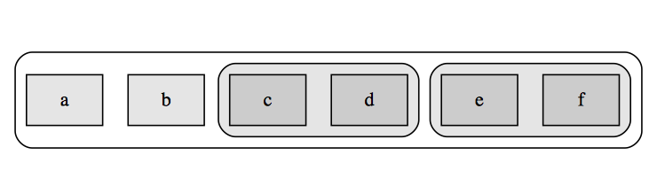

`list(a, b, list(c, d), list(e, f))`

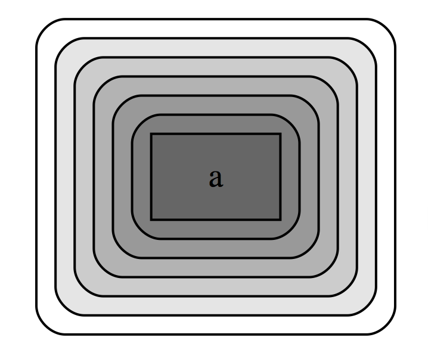

`list(list(list(list(list(list(a))))))`

### 2. What happens if you subset a tibble as if you’re subsetting a list? What are the key differences between a list and a tibble?

Subsetting a tibble and subsetting a list work the same way. The main difference between a list and a tibble is that all columns in a tibble must have the same number of rows, while lists can have vectors with different lengths.

```r
x <- tibble(a = 1:2, b = 3:4)
x[1]
```

```
## # A tibble: 2 x 1
##       a
##   <int>
## 1     1
## 2     2
```

```r
x[[1]]
```

```
## [1] 1 2
```

## 20.7.4 Exercises

### 1. What does `hms::hms(3600)` return? How does it print? What primitive type is the augmented vector built on top of? What attributes does it use?

```r
x <- hms::hms(3600)
typeof(x)
```

```
## [1] "double"
```

```r
attributes(x)
```

```
## $units
## [1] "secs"
##
## $class
## [1] "hms"      "difftime"
```

hms::hms(3600) prints the time (1 o’clock) in hh:mm:ss format. The primitive type is a double. The attributes it uses are `units` and `class`.

### 2. Try and make a tibble that has columns with different lengths. What happens?

```r
tibble(x = 1:3, y = 1:10)
```

```
## Error: Column `x` must be length 1 or 10, not 3
```

### 3. Based on the definition above, is it ok to have a list as a column of a tibble?

Yes, it is okay to have a list as a column of a tibble as long as it has the same length as other columns.

```r
tibble(x = 1:3, y = list("a", 1, list(1:3)))
```

```
## # A tibble: 3 x 2
##       x y
##   <int> <list>
## 1     1 <chr [1]>
## 2     2 <dbl [1]>
## 3     3 <list [1]>
```

## 21.2.1 Exercises

### 1. Write for loops to: 1) Compute the mean of every column in `mtcars`. 2) Determine the type of each column in `nycflights13::flights`. 3) Compute the number of unique values in each column of `iris`. 4) Generate 10 random normals for each of μ = −10, 0, 10, and 100. Think about the output, sequence, and body before you start writing the loop.

```r
mean_col <-  vector("double", ncol(mtcars))
names(mean_col) <-  names(mtcars)
for (i in names(mtcars)) {
  mean_col[[1]] <-  mean(mtcars[[i]])
}
mean_col
```

```
##    mpg    cyl   disp     hp   drat     wt   qsec     vs     am   gear
## 2.8125 0.0000 0.0000 0.0000 0.0000 0.0000 0.0000 0.0000 0.0000 0.0000
##   carb
## 0.0000
```

```r
data("flights", package = "nycflights13")
type_col <- vector("list", ncol(flights))
names(type_col) <- names(flights)
for (i in names(flights)) {
  type_col[[i]] <- class(flights[[i]])
}
type_col
```

```
## $year
## [1] "integer"
##
## $month
## [1] "integer"
##
## $day
## [1] "integer"
##
## $dep_time
## [1] "integer"
##
## $sched_dep_time
## [1] "integer"
##
## $dep_delay
## [1] "numeric"
##
## $arr_time
## [1] "integer"
##
## $sched_arr_time
## [1] "integer"
##
## $arr_delay
## [1] "numeric"
##
## $carrier
## [1] "character"
##
## $flight
## [1] "integer"
##
## $tailnum
## [1] "character"
##
## $origin
## [1] "character"
##
## $dest
## [1] "character"
##
## $air_time
## [1] "numeric"
##
## $distance
## [1] "numeric"
##
## $hour
## [1] "numeric"
##
## $minute
## [1] "numeric"
##
## $time_hour
## [1] "POSIXct" "POSIXt"
```

```r
data("iris")
unique_iris <- vector("double", ncol(iris))
names(unique_iris) <- names(iris)
for (i in names(iris)) {
  unique_iris[i] <- length(unique(iris[[i]]))
}
unique_iris
```

```
## Sepal.Length  Sepal.Width Petal.Length  Petal.Width      Species
##           35           23           43           22            3
```

```r
n <- 10
u <- c(-10, 0, 10, 100)
normals <- vector("list", length(u))
for (i in seq_along(normals)) {
  normals[[i]] <- rnorm(n, mean = u[i])
}
normals
```

```
## [[1]]
##  [1]  -9.441466 -11.280660  -9.985216 -10.636493  -8.956157  -8.679610
##  [7]  -9.626931 -10.352741 -10.137817 -10.748788
##
## [[2]]
##  [1] -0.55851553 -0.09162949 -1.09699337  0.18345295 -0.46241406
##  [6] -0.06587905 -0.92140001 -0.56890663 -1.92824035  1.64510781
##
## [[3]]
##  [1] 10.172696 12.566999  8.161949 10.366412 10.181025 10.586571 10.886820
##  [8]  9.810796 11.014485 10.574149
##
## [[4]]
##  [1] 101.17255  99.99888 100.29682 100.90236  98.06835 100.06888 100.67366
##  [8]  99.59091  98.89589  96.22406
```

### 2. Eliminate the for loop in each of the following examples by taking advantage of an existing function that works with vectors:

```r
# 1)
out <- ""
for (x in letters) {
  out <- stringr::str_c(out, x)
}
out
```

```
## [1] "abcdefghijklmnopqrstuvwxyz"
```

```r
# 2)
x <- sample(100)
sd <- 0
for (i in seq_along(x)) {
  sd <- sd + (x[i] - mean(x)) ^ 2
}
sd <- sqrt(sd / (length(x) - 1))
sd
```

```
## [1] 29.01149
```

```r
# 3)
x <- runif(100)
out <- vector("numeric", length(x))
out[1] <- x[1]
for (i in 2:length(x)) {
  out[i] <- out[i - 1] + x[i]
}
out
```

```
##   [1]  0.5988499  1.5393385  1.7126931  2.3822233  2.7220822  3.7002465
##   [7]  4.5378838  5.5310281  5.9310996  6.0683682  6.4792985  7.4667619
##  [13]  7.6181090  7.9146698  8.0813977  8.7946985  9.3730104  9.7415099
##  [19] 10.0031204 10.2300279 10.7504848 11.0846735 11.4993574 12.0757830
##  [25] 12.3300530 13.1595077 13.3217774 14.1866775 14.5379333 14.5494055
##  [31] 14.7303803 15.3423128 16.2308272 16.4604262 17.4429127 18.0754960
##  [37] 18.4325746 19.0029749 19.6197592 20.1730070 20.4955513 20.7336523
##  [43] 21.3835613 21.8979558 22.3853843 23.0775273 23.5306211 23.9390821
##  [49] 24.3114033 24.8550318 25.5026311 26.3845687 27.0218485 27.7199348
##  [55] 27.8078257 28.3607074 28.5661446 28.8068327 29.0026989 29.5960675
##  [61] 30.3253076 31.0245570 31.9844629 32.7462125 33.6599049 34.1173524
##  [67] 34.3677817 35.2257916 35.8808384 36.7666104 37.6997484 38.2078178
##  [73] 38.8959381 39.2914642 39.9535241 40.5270097 40.8609207 41.5813342
##  [79] 42.4695841 42.6449310 42.6713715 42.8435581 43.5006120 44.4154907
##  [85] 44.6546424 45.2935780 45.6022447 45.6579277 46.5359112 47.2803148
##  [91] 48.0436595 48.9101125 49.5211062 50.4549274 51.0084890 51.2604454
##  [97] 51.9690899 52.0334754 52.9636375 53.1596229
```

```r
stringr::str_c(letters, collapse = "")
```

```
## [1] "abcdefghijklmnopqrstuvwxyz"
```

```r
x <- sample(100)
sd(x)
```

```
## [1] 29.01149
```

```r
x <- runif(100)
cumsum(x)
```

```
##   [1]  0.9408839  1.0539824  2.0252742  2.5610731  3.3829579  3.3939465
##   [7]  3.4096772  3.5972565  3.9163755  4.3992952  4.8300783  5.5225916
##  [13]  5.8624987  5.9122008  6.0051527  6.7347012  7.0440094  7.6115206
##  [19]  8.3978830  8.6786213  9.0386053  9.1182204  9.3922304  9.4989410
##  [25] 10.2062573 11.1004650 11.5865406 12.0081732 12.7716850 12.9049934
##  [31] 13.1790284 13.5989757 14.1264246 14.4460189 14.6694547 15.3377629
##  [37] 16.0905743 16.5577884 16.5997978 17.5535108 18.4185094 18.5316158
##  [43] 19.4561121 19.8496400 20.2294239 20.2669653 20.9125745 21.0717566
##  [49] 21.3318175 21.7484266 22.6513346 23.3052125 23.9009292 24.3042542
##  [55] 25.2800455 25.9734806 26.3572273 26.9669328 27.3365267 27.4159056
##  [61] 27.7184858 28.3790987 28.9826100 29.4148630 29.4181651 29.9015695
##  [67] 30.1026968 30.8020582 31.3797954 31.3930404 31.3998601 32.0176208
##  [73] 32.5060203 32.8849641 33.5493687 34.0382433 34.7963809 35.3928669
##  [79] 35.7155584 36.3362542 36.4628699 36.7621195 37.5237972 37.5704529
##  [85] 38.2789938 38.7776859 38.9434806 39.5648075 40.3730593 40.5895550
##  [91] 41.4793810 42.1892987 42.7331956 43.0524484 43.3333003 43.3351716
##  [97] 43.6450541 44.1760551 44.8203379 44.9682270
```

### 3. Combine your function writing and for loop skills: 1) Write a for loop that `prints()` the lyrics to the children’s song “Alice the camel”. 2) Convert the nursery rhyme “ten in the bed” to a function. Generalise it to any number of people in any sleeping structure. 3) Convert the song “99 bottles of beer on the wall” to a function. Generalise to any number of any vessel containing any liquid on any surface.

```r
humps <- c("five", "four", "three", "two", "one", "no")
for (i in humps) {
  cat(str_c("Alice the camel has ", rep(i, 3), " humps.",
             collapse = "\n"), "\n")
  if (i == "no") {
    cat("Now Alice is a horse.\n")
  } else {
    cat("So go, Alice, go.\n")
  }
  cat("\n")
}
```

```
## Alice the camel has five humps.
## Alice the camel has five humps.
## Alice the camel has five humps.
## So go, Alice, go.
##
## Alice the camel has four humps.
## Alice the camel has four humps.
## Alice the camel has four humps.
## So go, Alice, go.
##
## Alice the camel has three humps.
## Alice the camel has three humps.
## Alice the camel has three humps.
## So go, Alice, go.
##
## Alice the camel has two humps.
## Alice the camel has two humps.
## Alice the camel has two humps.
## So go, Alice, go.
##
## Alice the camel has one humps.
## Alice the camel has one humps.
## Alice the camel has one humps.
## So go, Alice, go.
##
## Alice the camel has no humps.
## Alice the camel has no humps.
## Alice the camel has no humps.
## Now Alice is a horse.
```

```r
numbers <- c("ten", "nine", "eight", "seven", "six", "five",
             "four", "three", "two", "one")
for (i in numbers) {
  cat(str_c("There were ", i, " in the bed\n"))
  cat("and the little one said\n")
  if (i == "one") {
    cat("I'm lonely...")
  } else {
    cat("Roll over, roll over\n")
    cat("So they all rolled over and one fell out.\n")
  }
  cat("\n")
}
```

```
## There were ten in the bed
## and the little one said
## Roll over, roll over
## So they all rolled over and one fell out.
##
## There were nine in the bed
## and the little one said
## Roll over, roll over
## So they all rolled over and one fell out.
##
## There were eight in the bed
## and the little one said
## Roll over, roll over
## So they all rolled over and one fell out.
##
## There were seven in the bed
## and the little one said
## Roll over, roll over
## So they all rolled over and one fell out.
##
## There were six in the bed
## and the little one said
## Roll over, roll over
## So they all rolled over and one fell out.
##
## There were five in the bed
## and the little one said
## Roll over, roll over
## So they all rolled over and one fell out.
##
## There were four in the bed
## and the little one said
## Roll over, roll over
## So they all rolled over and one fell out.
##
## There were three in the bed
## and the little one said
## Roll over, roll over
## So they all rolled over and one fell out.
##
## There were two in the bed
## and the little one said
## Roll over, roll over
## So they all rolled over and one fell out.
##
## There were one in the bed
## and the little one said
## I'm lonely...
```

```r
bottles <- function(i) {
  if (i > 2) {
   bottles <- str_c(i - 1, " bottles")
  } else if (i == 2) {
   bottles <- "1 bottle"
  } else {
   bottles <- "no more bottles"
  }
  bottles
}

beer_bottles <- function(n) {
  # should test whether n >= 1.
  for (i in seq(n, 1)) {
     cat(str_c(bottles(i), " of beer on the wall, ", bottles(i), " of beer.\n"))
     cat(str_c("Take one down and pass it around, ", bottles(i - 1),
                " of beer on the wall.\n\n"))
  }
  cat("No more bottles of beer on the wall, no more bottles of beer.\n")
  cat(str_c("Go to the store and buy some more, ", bottles(n), " of beer on the wall.\n"))
}
beer_bottles(5)
```

```
## 4 bottles of beer on the wall, 4 bottles of beer.
## Take one down and pass it around, 3 bottles of beer on the wall.
##
## 3 bottles of beer on the wall, 3 bottles of beer.
## Take one down and pass it around, 2 bottles of beer on the wall.
##
## 2 bottles of beer on the wall, 2 bottles of beer.
## Take one down and pass it around, 1 bottle of beer on the wall.
##
## 1 bottle of beer on the wall, 1 bottle of beer.
## Take one down and pass it around, no more bottles of beer on the wall.
##
## no more bottles of beer on the wall, no more bottles of beer.
## Take one down and pass it around, no more bottles of beer on the wall.
##
## No more bottles of beer on the wall, no more bottles of beer.
## Go to the store and buy some more, 4 bottles of beer on the wall.
```

### 4. It’s common to see for loops that don’t preallocate the output and instead increase the length of a vector at each step:

```
output <- vector("integer", 0)
for (i in seq_along(x)) {
  output <- c(output, lengths(x[[i]]))
}
output
```

### How does this affect performance? Design and execute an experiment.

(Using package `microbenchmark` to time execution of R expressions)

```r
library(microbenchmark)
```

No preallocation:

```r
non_allocate <- function(n) {
  output <- vector("integer", 0)
  for (i in seq_len(n)) {
    output <- c(output, i)
  }
  output
}
microbenchmark(non_allocate(10000), times = 10)
```

```
## Unit: milliseconds
##                 expr      min       lq     mean  median       uq     max
##  non_allocate(10000) 166.2248 169.9118 185.5788 181.315 188.8407 241.181
##  neval
##     10
```

With preallocation:

```r
allocate <- function(n) {
  output <- vector("integer", n)
  for (i in seq_len(n)) {
    output[[i]] <- i
  }
  output
}
microbenchmark(allocate(10000), times = 10)
```

```
## Unit: milliseconds
##             expr      min       lq     mean   median       uq      max
##  allocate(10000) 6.591172 7.134392 8.391628 8.315871 9.253837 11.30975
##  neval
##     10
```

Loops that preallocate the output run much faster.

## 21.3.5 Exercises

### 1. Imagine you have a directory full of CSV files that you want to read in. You have their paths in a vector, `files <- dir("data/", pattern = "\\.csv$", full.names = TRUE)`, and now want to read each one with `read_csv()`. Write the for loop that will load them into a single data frame.

```
df <- vector("list", length(files))
for (fname in seq_along(files)) {
  df[[i]] <- read_csv(files[[i]])
}
df <- bind_rows(df)
```

### 2. What happens if you use for `(nm in names(x))` and `x` has no names? What if only some of the elements are named? What if the names are not unique?

If `x` has no names, then nothing happens (the loop is run 0 times). If only some of the elements are named, then the empty name is filled with “” and there is an error when trying to access the value of the un-named element. If the names are not unique, then only the first element with the duplicate name is accessed.

```r
x <- 1:5
for (nm in names(x)) {
  print(nm)
  print(x[[nm]])
}
```

```r
x <- c(a = 1, 2, c = 3)
for (nm in names(x)) {
  print(nm)
  print(x[[nm]])
}
```

```
## [1] "a"
## [1] 1
## [1] ""
```

```
## Error in x[[nm]]: subscript out of bounds
```

```r
x <- c(a = 1, a = 2, c = 3)
for (nm in names(x)) {
  print(nm)
  print(x[[nm]])
}
```

```
## [1] "a"
## [1] 1
## [1] "a"
## [1] 1
## [1] "c"
## [1] 3
```

### 3. Write a function that prints the mean of each numeric column in a data frame, along with its name. For example, `show_mean(iris)` would print:

```
show_mean(iris)
#> Sepal.Length: 5.84
#> Sepal.Width:  3.06
#> Petal.Length: 3.76
#> Petal.Width:  1.20
```

```r
col_mean <- function(x) {
  classes <- vector("logical", length(x))
  for (i in seq_along(x)) classes[[i]] <- is.numeric(x[[i]])
  x <- x[classes]
  for (i in seq_along(x)) {
    cat(paste0(names(x)[i], ": ", round(mean(x[[i]]), 2)), fill = TRUE)
  }
}
col_mean(iris)
```

```
## Sepal.Length: 5.84
## Sepal.Width: 3.06
## Petal.Length: 3.76
## Petal.Width: 1.2
```

### 4. What does this code do? How does it work?

```r
trans <- list(
  disp = function(x) x * 0.0163871,
  am = function(x) {
    factor(x, labels = c("auto", "manual"))
  }
)
for (var in names(trans)) {
  mtcars[[var]] <- trans[[var]](mtcars[[var]])
}
```

This code multiplies `disp` by 0.0163871 and converts `am` into a factor. The code then loops over a named list of functions, calling each function in the list on the corresponding column of `mtcars` and replacing the values in that column.

## 21.4.1 Exercises

### 1. Read the documentation for `apply()`. In the 2d case, what two for loops does it generalise?

It generalizes looping over the rows or columns of an array or matrix.

### 2. Adapt `col_summary()` so that it only applies to numeric columns. You might want to start with an `is_numeric()` function that returns a logical vector that has a TRUE corresponding to each numeric column.

```r
col_summary <- function(x) {
  col_numeric <- vector("logical", length(x))
  for (i in seq_along(x)) {
    col_numeric[[i]] <- is.numeric(x[[i]])
  }
  x <- x[col_numeric]
  output <- vector("numeric", length(x))
  for (i in seq_along(x)) {
    output[[i]] <- mean(x[[i]])
  }
  output
}
col_summary(iris)
```

```
## [1] 5.843333 3.057333 3.758000 1.199333
```

## 21.5.3 Exercises

### 1. Write code that uses one of the map functions to: 1) Compute the mean of every column in `mtcars`. 2) Determine the type of each column in `nycflights13::flights`. 3) Compute the number of unique values in each column of `iris`. 4) Generate 10 random normals for each of μ = −10, 0, 10, and 100.

```r
map_dbl(mtcars, mean)
```

```
##        mpg        cyl       disp         hp       drat         wt
##  20.090625   6.187500   3.780862 146.687500   3.596563   3.217250
##       qsec         vs         am       gear       carb
##  17.848750   0.437500         NA   3.687500   2.812500
```

```r
map(nycflights13::flights, typeof)
```

```
## $year
## [1] "integer"
##
## $month
## [1] "integer"
##
## $day
## [1] "integer"
##
## $dep_time
## [1] "integer"
##
## $sched_dep_time
## [1] "integer"
##
## $dep_delay
## [1] "double"
##
## $arr_time
## [1] "integer"
##
## $sched_arr_time
## [1] "integer"
##
## $arr_delay
## [1] "double"
##
## $carrier
## [1] "character"
##
## $flight
## [1] "integer"
##
## $tailnum
## [1] "character"
##
## $origin
## [1] "character"
##
## $dest
## [1] "character"
##
## $air_time
## [1] "double"
##
## $distance
## [1] "double"
##
## $hour
## [1] "double"
##
## $minute
## [1] "double"
##
## $time_hour
## [1] "double"
```

```r
map(iris, ~ length(unique(.)))
```

```
## $Sepal.Length
## [1] 35
##
## $Sepal.Width
## [1] 23
##
## $Petal.Length
## [1] 43
##
## $Petal.Width
## [1] 22
##
## $Species
## [1] 3
```

```r
map(c(-10, 0, 10, 100), ~ rnorm(n = 10, mean = .))
```

```
## [[1]]
##  [1] -10.498476  -7.958647  -9.923879  -9.350157 -11.203245  -8.852508
##  [7] -11.321662 -10.377710  -8.556311 -10.349295
##
## [[2]]
##  [1] -0.2679194  0.7503418 -2.4202049 -0.2795463 -2.3175119  0.3006600
##  [7] -0.2994569 -0.1327074  0.4585322  0.9943150
##
## [[3]]
##  [1]  8.642762 11.088917 10.142365 10.907140  9.498273  9.581188  9.484075
##  [8] 10.509895  9.918316  8.366754
##
## [[4]]
##  [1]  98.62661  99.67109 100.93621  99.29925  99.01066  99.48367 100.77843
##  [8] 101.10969 100.68043 101.67924
```

### 2. How can you create a single vector that for each column in a data frame indicates whether or not it’s a factor?

```r
map_lgl(iris, is.factor)
```

```
## Sepal.Length  Sepal.Width Petal.Length  Petal.Width      Species
##        FALSE        FALSE        FALSE        FALSE         TRUE
```

### 3. What happens when you use the map functions on vectors that aren’t lists? What does `map(1:5, runif)` do? Why?

```r
x <- map(1:5, runif)
x
```

```
## [[1]]
## [1] 0.5513507
##
## [[2]]
## [1] 0.6983527 0.2254573
##
## [[3]]
## [1] 0.0265623 0.9110533 0.9068626
##
## [[4]]
## [1] 0.3570377 0.3545317 0.4143352 0.9154181
##
## [[5]]
## [1] 0.1353142 0.5379768 0.1793350 0.5995527 0.2692308
```

When you use map functions on vectors that aren’t lists, then they still iterate over the vector elements. `map(1:5, runif)` is equivalent to running runif(1), runif(2), …, runif(5), and then collecting the results in a list (end up with a list with five numeric vectors inside of it ranging from size 1 to size 5).

### 4. What does `map(-2:2, rnorm, n = 5)` do? Why? What does `map_dbl(-2:2, rnorm, n = 5)` do? Why?

```r
map(-2:2, rnorm, n = 5)
```

```
## [[1]]
## [1] -2.177175 -1.324815 -2.170683 -1.879345 -2.037739
##
## [[2]]
## [1] -0.9838329 -1.1733771 -1.9262037 -2.2187200 -0.4383337
##
## [[3]]
## [1] -0.14663936  0.39709406  1.51724177 -0.07099659 -0.91583239
##
## [[4]]
## [1] 2.2245930 0.9023875 0.1009739 0.4756838 0.1575837
##
## [[5]]
## [1] 1.180080 1.762645 1.109094 1.275070 1.750406
```

```r
map_dbl(-2:2, rnorm, n = 5)
```

```
## Error: Result 1 is not a length 1 atomic vector
```

`map(-2:2, rnorm, n = 5)` runs rnorm with mean -2, then -1, …, 2, returning a list of 5 vectors, each with size 5. On the other hand, `map_dbl(-2:2, rnorm, n = 5)` does the same thing but also checks that the result is of type double and has a length of 1 (throws an error because doesn’t have length of 1).

### 5. Rewrite `map(x, function(df) lm(mpg ~ wt, data = df))` to eliminate the anonymous function.

```
map(x, ~ lm(mpg ~ wt, data = .))
```

## 21.9.3 Exercises

### 1. Implement your own version of `every()` using a for loop. Compare it with `purrr::every()`. What does purrr’s version do that your version doesn’t?

```r
every_2 <- function(.x, .p, ...) {
  for (i in .x) {
    if (!.p(i, ...)) {
      return(FALSE)
    }
  }
  TRUE
}

every_2(1:5, function(x) {x > 1})
```

```
## [1] FALSE
```

purrr’s version is able to do more things with .p (ex. taking a logical vector) and probably runs faster.

### 2. Create an `enhanced col_sum()` that applies a summary function to every numeric column in a data frame.

```r
enhanced_col_sum <- function(df, f, ...) {
  map(keep(df, is.numeric), f, ...)
}
enhanced_col_sum(iris, mean)
```

```
## $Sepal.Length
## [1] 5.843333
##
## $Sepal.Width
## [1] 3.057333
##
## $Petal.Length
## [1] 3.758
##
## $Petal.Width
## [1] 1.199333
```

### 3. A possible base R equivalent of `col_sum()` is:

```r
col_sum3 <- function(df, f) {
  is_num <- sapply(df, is.numeric)
  df_num <- df[, is_num]

  sapply(df_num, f)
}
```

### But it has a number of bugs as illustrated with the following inputs:

```r
df <- tibble(
  x = 1:3,
  y = 3:1,
  z = c("a", "b", "c")
)
col_sum3(df, mean)
```

```
## x y
## 2 2
```

```r
# Has problems: don't always return numeric vector
col_sum3(df[1:2], mean)
```

```
## x y
## 2 2
```

```r
col_sum3(df[1], mean)
```

```
## x
## 2
```

```r
col_sum3(df[0], mean)
```

```
## Error: Unsupported index type: list
```

### What causes the bugs?

The bugs are caused by the fact that `sapply` does not always produce the same type of output - for example, `sapply(df[0], is.numeric)` returns a named list while `sapply(df[1], is.numeric)` returns a logical vector.

```r
x <- sapply(df[0], is.numeric)
typeof(x)
```

```
## [1] "list"
```

```r
y <- sapply(df[1], is.numeric)
typeof(y)
```

```
## [1] "logical"
```